# BIOS2 - Sentinelle Nord - Advanced Field School in Computational Ecology

Predicting optimal foraging behaviour in TrophIE using a nested patch model

Daniel Fortin : *developed the code for the models

Département de Biologie & Centre d’Étude de la Forêt, Université Laval  
Daniel.Fortin@bio.ulaval.ca

Maxime Fraser Franco : *developed the R markdown document

Département des Sciences Biologiques & Centre de la Science de la Biodiversité du Québec, Université du Québec à Montréal  
fraser_franco.maxime@courrier.uqam.ca

21 May, 2023

# 1 Overview

This tutorial is part of the behavioural ecology work package presented during the [Sentinelle Nord advanced field school in computational ecology](http://dev.sentinellenord.ulaval.ca/en/ecology2023) held in May 2023 in Val-Morin, Québec, Canada.

Optimal diet and optimal residency time can be combined in a hierarchical model of optimal foraging in patchy landscapes (McNamara, Houston, and Weisser 1993). Prey then have to decide which prey type(s) should be consumed in each patch, and when they should leave the current patch. In risky environments, their decisions should also consider their risk of mortality when involved in different behaviour. Optimal decisions thus depend on multiple factors, including the risk of predation, the level of safety provided by refuges, the time required to handle each resource, and the gain that comes with handling a given resource. In this tutorial, we will discuss how such set of optimal decisions can be identified from ecological theory.

# 2 Case study

#### Multi-level foraging decisions of prey under predation risk in a landscape with refuges: How to become the richest possible!

What are the optimal multi-level foraging decisions under these conditions? We estimate this optimality problem numerically through a two-step process. First, we estimate the gain that can be expected within patches from the different possible foraging decisions. Each set of decisions made in a given patch results in a specific gain $(g)$ achieved during the associated residence time $(t)$. Second, we use this information [$g(t), t$] as input to the inter-patch model to estimate the overall realized gain that can be expected during $T_{f}$ = 30 min, given the global survival probability. Although a PowerPoint presentation details the modeling approach, below we summarize the general method through an example.

# 3 Within-patch model

## 3.1 Model parameters

A critical step is to determine the gain function, which depends on the drawing rate of marbles, the number of marbles of the different types, and whether or not a given type is collected, as well as its handling time and value.

```r
Tf <- 30               # game duration
N_in_t0 <- 50          # total number of marbles at a given station at the beginning
N1_in_t0 <- 10         # marbles of type 1 at the beginning
N2_in_t0 <- N1_in_t0   # marbles of type 2 at the beginning

Nsubstrat <- N_in_t0 - (N1_in_t0 + N2_in_t0)

lambda_in <- (60 / 10) # searching rate when not handling (marbles that can be drawn / min)
h1_in <- (10 / 60)     # handling time resource type 1 (min / marble)
h2_in <- (10 / 60)     # handling time resource type 2 (min / marble)

e1_in <- 5            # $ gained by consuming a resource of type 1 ($ / marble)
e2_in <- 1            # $ gained by consuming a resource of type 2 ($ / marble)
p1_in <- 1             # if marble of type 1 are taken, p = 1; 0 otherwise
p2_in <- 1             # if marble of type 2 are taken, p = 1; 0 otherwise
```

## 3.2 Building the model

We now estimate the first step of the gain function $g(0)$, which starts when the prey arrive at the patch. We consider a typical type II functional response (Fryxell and Lundberg 1997), where the encounter rate with each type of marble is the product of the “number of marbles that can be drawn per minute (i.e., `lambda_in`)” and the “proportion of that type of marble available in the bag” upon arrival at the patch (i.e., `N1_in_t0 / N_in_t0`).

```r
E_in_t0 <- ((lambda_in * (N1_in_t0 / N_in_t0) * e1_in * p1_in) +
            (lambda_in * (N2_in_t0 / N_in_t0) * e2_in * p2_in)) /
            (1 + (lambda_in * (N1_in_t0 / N_in_t0) * h1_in * p1_in) +
            (lambda_in * (N2_in_t0 / N_in_t0) * h2_in * p2_in))


cons1_in_T0 <- (lambda_in * (N1_in_t0 / N_in_t0) * p1_in) /
               (1 + (lambda_in * (N1_in_t0 / N_in_t0) * h1_in * p1_in) +
               (lambda_in * (N2_in_t0 / N_in_t0) * h2_in * p2_in))


cons2_in_T0 <- (lambda_in * (N2_in_t0 / N_in_t0) * p2_in) /
               (1 + (lambda_in * (N1_in_t0 / N_in_t0) * h1_in * p1_in) +
               (lambda_in * (N2_in_t0 / N_in_t0) * h2_in * p2_in))
```

Here, we define the starting values and create empty vectors that will be filled.

```r
E_in_t <- E_in_t0
#cumE_in_t <- E_in_t0
N1_in_t <- N1_in_t0
N2_in_t <- N2_in_t0
N_in_t <- N_in_t0
vN1_in_t <- numeric()
vN2_in_t <- numeric()
vN_in_t <- numeric()
vE_in_t <- numeric()
vnum <- numeric()
vdenom <- numeric()
```

## 3.3 Run the model

We estimate the expected temporal changes in the number of marbles available at the end of each time step for each marble type, and use this information to calculate the gain function (`E_in_t`).

```r
for (i in 1:(Tf - 1)) {

  N1_in_t <- N1_in_t -
            ((lambda_in * (N1_in_t / N_in_t) * p1_in) /
             (1 + (lambda_in * (N1_in_t / N_in_t) * h1_in * p1_in) +
             (lambda_in * (N2_in_t / N_in_t) * h2_in * p2_in))
            )

  N2_in_t <- N2_in_t -
             ((lambda_in * (N2_in_t / N_in_t) * p2_in) /
              (1 + (lambda_in * (N1_in_t / N_in_t) * h1_in * p1_in) +
              (lambda_in * (N2_in_t / N_in_t) * h2_in * p2_in))
             )

  #E_in_t <- ((lambda_in * (N1_in_t / N_in_t) * e1_in * p1_in) +
  #           (lambda_in * (N2_in_t / N_in_t) * e2_in * p2_in)
  #          ) /
  #          (1 + (lambda_in * (N1_in_t / N_in_t) * h1_in * p1_in) +
  #           (lambda_in * (N2_in_t / N_in_t) * h2_in * p2_in)
  #          )

  N_in_t <- N1_in_t + N2_in_t + Nsubstrat

  num  <- (lambda_in * (N1_in_t / N_in_t) * e1_in * p1_in) +
          (lambda_in * (N2_in_t / N_in_t) * e2_in * p2_in)

  denom <- 1 +
           (lambda_in * (N1_in_t / N_in_t) * h1_in * p1_in) +
           (lambda_in * (N2_in_t / N_in_t) * h2_in * p2_in)

  vN1_in_t[i] <- (N1_in_t)
  vN2_in_t[i] <- (N2_in_t)
  vN_in_t[i] <- (N_in_t)
  #vE_in_t[i] <- (E_in_t)

  vnum[i] <- (num)
  vdenom[i] <- (denom)

}
```

## 3.4 Visualize the predictions

We can see that, under these rules, the rate of gain slows down over time.

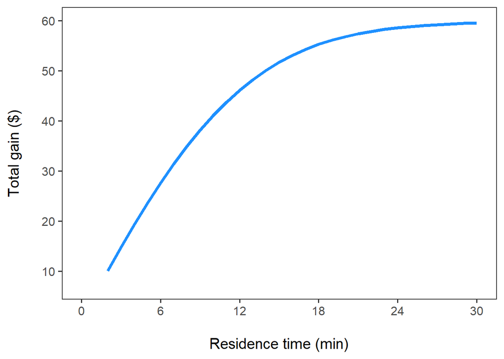

```r
# Extract parameters
E_in <- vnum / vdenom             # rate of $ collection
E_in1 <- append((E_in_t0), E_in)

totgain_temp <- cumsum(E_in1)     # gain function (for each min)
totgain <- totgain_temp[1:Tf]     # gain function only during Tf

Residencytime <- 1:Tf

# Plot
library(ggplot2)
dat <- data.frame(x = Residencytime, y = totgain)

ggplot(data = dat, aes(x = x, y = y)) +
    geom_line(linewidth = 1.5, color = "dodgerblue") +
    xlab("\nResidence time (min)") +
    ylab("Total gain ($)\n") +
    scale_x_continuous(breaks = seq(0, 30, 6), limits = c(0, 30)) +
    scale_y_continuous(breaks = seq(0, 60, 10), limits = c(7, 60)) +
    theme_bw(base_size = 15) +
    theme(panel.grid = element_blank())
```

# 4 Among-patch model

Now that we have determined the expected gain at a patch, given the choice of marble type and the time spent at each patch, we can use this information to estimate the overall gain that can be expected at the end of the allowed 30 minutes.

## 4.1 Model parameters

This estimation will depend on the encounter rate with patches when searching. We thus need to take into account the density of marble bags and the area that can be searched per unit of time, which in turn, depends on travel speed and the area that can be scanned while travelling. We must also consider predation risk (through the probability of survival) when involved in different behaviours.

```r
a <- 30 * 23       # area search rate (m2 / min) (i.e. width * speed)
N1 <- 100 / 112000 # path density  (patches / m2) (i.e., 100 patches in about 120 000 m2)
#N2 <- N1          # density of patch type 2  (patches / m2) (not considered in the game)
mus <- 0.5         # survival probability when travelling between patches
muh <- mus         # survival probability when at a patch (i.e. when handling marbles)
mur <- .9          # survival probability when in refuge
#p1 <- 1
#p2 <- 0           # p2 always 0 because only one type of resource patches

hx <- 1:Tf         # h: min spent in a patch handing marbles
```

We create vector values that will be used in the calculation.

```r
# encounter (patch/min) * handling a patch (min/patch)
Trx <- 1:Tf
hpatcha <- c(rep(hx, times = length(Trx)))
totgain1 <- c(rep(totgain, times = length(Trx)))
Tr <- c(rep(Trx, each = length(hx)))
```

Because you specifically have 30 min to collect marbles, we consider the behaviour you will be specifically doing when the time is up. For example, you may not be able to spent the time you wanted in the last patch. The approach below considers this possibility when calculating the overall gain that can be expected in 30 minutes. The model provides estimates of the optimal time spent in refuges, searching for marble patches, and collecting marbles in patches, given your foraging choice and the risk of predation.

As you will see, the model does not directly identify the optimal diet. To determine the most rewarding choice, all you have to do is estimate the long-term expected payouts if you collect only one type of marble, and if you collect both. You will then be able to directly see which strategy offers the highest expected gains. The model provides an estimate of the time that should be spent in refuges, at marble patches, and moving between patches, to maximize your gains, given the long-term probability of survival.

```r
Alldata1 <- matrix(c(Tr, hpatcha, totgain1), nrow = (length(Tr)), ncol = 3)
colnames(Alldata1) <- c("Tr", "hpatch", "e_intra")

# Encounter rate (m2 / min * patch / m2 = patch / min) with patch of type 1
# (only this type present)
lambdaAll1 <- a * N1

# Expected number of minutes needed to encounter the next patch
Timepatch_enc1 <- 1 / lambdaAll1

# time spent in each patch + time to the next patch
timeto_search_handl1 <- Timepatch_enc1 + hpatcha

# total no of patches visited during Tf
tot_patch_process_during_Tf <- (Tf - Tr) / timeto_search_handl1
Num_patches <- tot_patch_process_during_Tf

# modulo to get min remaining
remaining <- (Tf - Tr) %% timeto_search_handl1
# if +, then can consume the last patch completely
# i.e. 2.7 patches --> 3 patches completely consumed
diff1 <- remaining - hpatcha

# number of patches fully handled
nb_patch_fullyhandl <- ifelse(
    diff1 < 0,
    floor(Num_patches), ceiling(Num_patches)
)

# gain in the last patch is not fully handled
bbbb <- ifelse(diff1 < 0, totgain_temp[remaining], 0)
# search time at the end. =0 if last patch not fully consumed, remaining otherwise
cccc <- ifelse(diff1 < 0, 0, diff1)
# time spent handling last patch if only partially consumed
dddd <- ifelse(diff1 < 0, remaining, 0)

gain_duringTf <- (nb_patch_fullyhandl * totgain1) + bbbb
Ts_inter <- (Timepatch_enc1 * (floor(Num_patches))) + cccc # assume that consumer starts in a patch
Th1 <- (hpatcha * nb_patch_fullyhandl) + dddd

# overall survival probability, given the time spent in different behaviours
# (searching, handling marbles at a station, waiting in a refuge)
mu <- ((Ts_inter * mus + Th1 * muh + Tr * mur) / Tf)

# Expected long term gain rate, given probability of survival
Eall1 <- gain_duringTf * mu

loc1 <- which(Eall1 == max(Eall1))

zz <- matrix(
    c(
     Eall1, gain_duringTf, mu,
     hpatcha, nb_patch_fullyhandl,
     Ts_inter, Th1, Tr
    ),
    ncol = 8
)
colnames(zz) <- c(
    "Eall", "E", "mu", "h",
    "NbPatch_consumed",
    "Ts", "Th", "Tr"
)
```

## 4.2 Visualize the predictions

Here, we generate a figure showing the gain rate ($ / time spent in patch) that can be expected in a patch, as a function of the time spent in that patch.

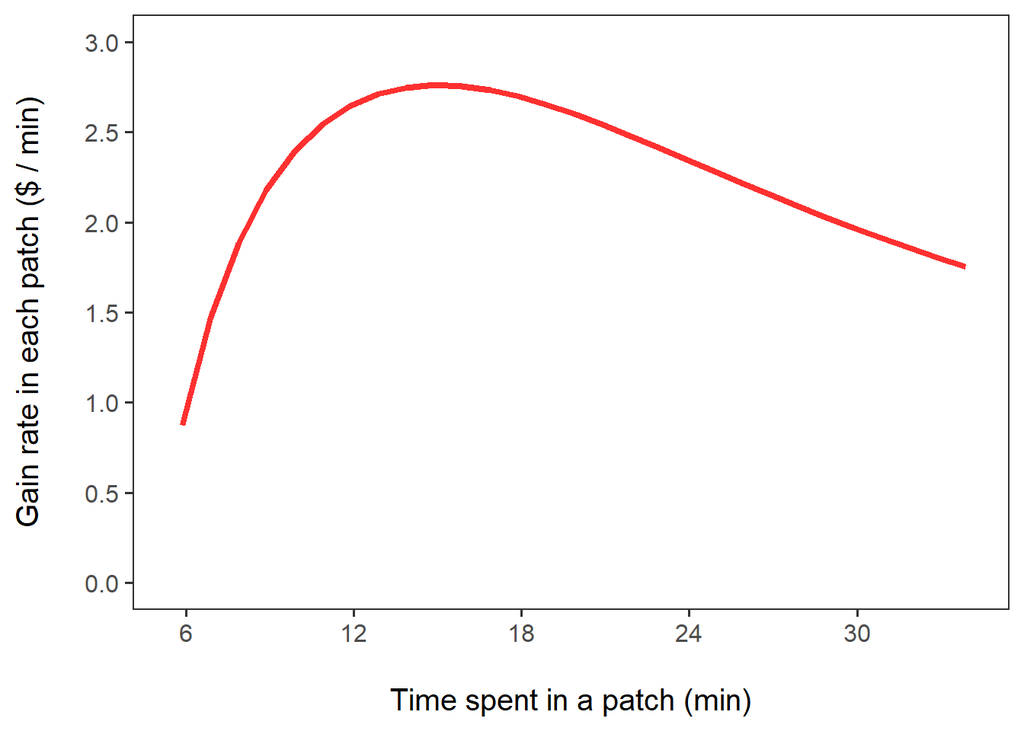

```r
# Extract model parameters
timex <- 1:length(totgain_temp)
timex <- timex + Ts_inter[loc1]
gain <- totgain_temp / timex
#gain2 <- Eall1/timex #plot(timex, gain)

dat <- data.frame(x = timex, y = gain)

# library(ggplot2)
ggplot(data = dat, aes(x = x, y = y)) +
    geom_line(linewidth = 1.5, color = "firebrick1") +
    xlab("\nTime spent in a patch (min)") +
    ylab("Gain rate in each patch ($ / min)\n") +
    scale_x_continuous(breaks = seq(0, 30, 6), limits = c(5.5, 34)) +
    scale_y_continuous(breaks = seq(0, 3, 0.5), limits = c(0, 3)) +
    theme_bw(base_size = 15) +
    theme(panel.grid = element_blank())
```

## 4.3 Results of the simulation

The following code generates two columns providing eight attributes of the simulation, including the behaviours yielding the highest payoffs, given the diet choice. We can look at the values by printing the `data.frame`.

```r
# Long-term expected gain, overall risk, handling rate
# number of stations fully consumed
# time spent searching, handling, in refuge
Value_given_optimal_behaviour <- c(
    Eall1[loc1], gain_duringTf[loc1],
    mu[loc1], hpatcha[loc1], nb_patch_fullyhandl[loc1],
    Ts_inter[loc1], Th1[loc1], Tr[loc1]
)

Value_given_optimal_behaviour <- round(
  Value_given_optimal_behaviour, digits = 2
)

# Long-term expected gain, overall risk, handling rate
# number of stations fully consumed
# time spent searching, handling, in refuge
Variable <- c(
  "Realized gain ($)", "gain_no_pred",
  "Overall survival probability", "Patch resience time (min)",
  "nb of patches fully handled", "Total time searching patches (min)",
  "Total time in patches (min)", "Total time in refuge (min)"
)

c <- data.frame(Variable = Variable, Value = Value_given_optimal_behaviour)

c
```

| Variable | Value |
| --- | --- |
| Realized gain ($) | 83.74 |
| gain_no_pred | 141.14 |
| Overall survival probability | 0.59 |
| Patch resience time (min) | 6.00 |
| nb of patches fully handled | 3.00 |
| Total time searching patches (min) | 4.87 |
| Total time in patches (min) | 18.13 |
| Total time in refuge (min) | 7.00 |

# References

Fryxell, John M., and Per Lundberg. 1997. *Individual Behavior and Community Dynamics*. Boston, MA: Springer US. https://doi.org/10.1007/978-1-4684-1421-9.

Houston, Alasdair I., and John M. McNamara. 2014. “Foraging Currencies, Metabolism and Behavioural Routines.” *Journal of Animal Ecology* 83 (1): 30–40. https://doi.org/10.1111/1365-2656.12096.

Kacelnik, Alejandro, and Innes Cuthill. 1990. “Central Place Foraging in Starlings (Sturnus Vulgaris). II. Food Allocation to Chicks.” *Journal of Animal Ecology* 59 (2): 655–74. https://doi.org/10.2307/4887.

MacArthur, Robert H., and Eric R. Pianka. 1966. “On Optimal Use of a Patchy Environment.” *The American Naturalist* 100 (916): 603–9. https://doi.org/10.1086/282454.

McNamara, John M., Alasdair I. Houston, and Wolfgang W. Weisser. 1993. “Combining Prey Choice and Patch Use - What Does Rate-maximizing Predict?” *Journal of Theoretical Biology* 164 (2): 219–38. https://doi.org/10.1006/jtbi.1993.1150.

Richardson, Howard, and Nicolaas A. M. Verbeek. 1986. “Diet Selection and Optimization by Northwestern Crows Feeding on Japanese Littleneck Clams.” *Ecology* 67 (5): 1219–26. https://doi.org/10.2307/1938677.

Sih, Andrew, and Bent Christensen. 2001. “Optimal Diet Theory: When Does It Work, and When and Why Does It Fail?” *Animal Behaviour* 61 (2): 379–90. https://doi.org/10.1006/anbe.2000.1592.